```python
# Importing libraries
import seaborn as sns
import numpy as np
```

```
Matplotlib is building the font cache; this may take a moment.
```

```python
# Reading the dataset
iris = sns.load_dataset('iris')
iris
```

|  | sepal_length | sepal_width | petal_length | petal_width | species |
| --- | --- | --- | --- | --- | --- |
| 0 | 5.1 | 3.5 | 1.4 | 0.2 | setosa |
| 1 | 4.9 | 3.0 | 1.4 | 0.2 | setosa |
| 2 | 4.7 | 3.2 | 1.3 | 0.2 | setosa |
| 3 | 4.6 | 3.1 | 1.5 | 0.2 | setosa |
| 4 | 5.0 | 3.6 | 1.4 | 0.2 | setosa |
| ... | ... | ... | ... | ... | ... |
| 145 | 6.7 | 3.0 | 5.2 | 2.3 | virginica |
| 146 | 6.3 | 2.5 | 5.0 | 1.9 | virginica |
| 147 | 6.5 | 3.0 | 5.2 | 2.0 | virginica |
| 148 | 6.2 | 3.4 | 5.4 | 2.3 | virginica |
| 149 | 5.9 | 3.0 | 5.1 | 1.8 | virginica |

150 rows × 5 columns

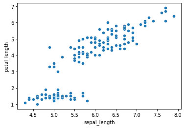

```python
# Scatterplot
sns.scatterplot(x = 'sepal_length', y = 'petal_length', data = iris)
```

Scatter plots are used to map distributions. From the above visualization, it is observed that an increasing sepal length shows an increase in the petal length. Majority of the petal lengths are concentrated in ranges 1-2 and 4-6.

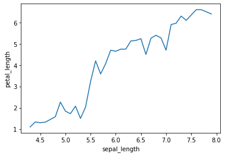

```python
# Lineplot
sns.lineplot(x = 'sepal_length', y = 'petal_length', data = iris, ci = None)
```

Line plots are used to show trends. From the above visualization, it is observed that an increasing sepal length more or less causes an increase in the petal length.

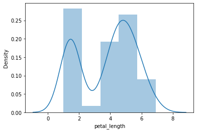

```python
# Distplot
sns.distplot(iris['petal_length'])
```

This distribution plot imparts that the majority petal lengths belong to the ranges 4-6, peaking at 5. Another peak is observed at the length from 1-2.

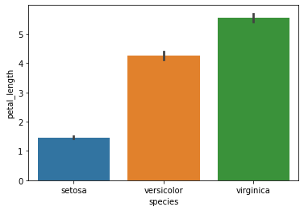

```python
# Barplot
sns.barplot(x = 'species', y = 'petal_length', data = iris)
```

The above bar plot conveys that the Virginica species have the longest petals, while that of the Setosa have the shortest.

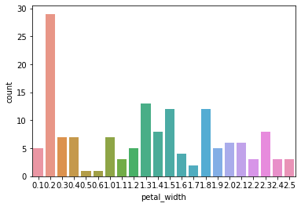

```python
# Countplot
sns.countplot(x = 'petal_width', data = iris)
```

The count plot suggests that having a petal width of 0.2 is the most common among the species, while the widths 0.5 and 0.6 are the rarest.

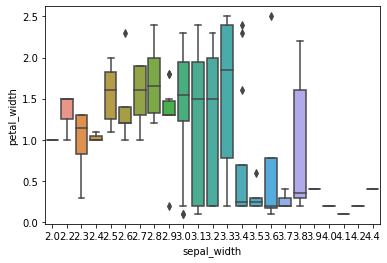

```python
# Box plot
sns.boxplot(x = 'sepal_width', y = 'petal_width', data = iris)
```

Box plots are used to represent statistical data, making it easy to identify outliers. This plot is drawn sepal width against petal width, illustrating the min and max petal widths with respect to their sepal widths. For instance, species having a sepal width of 3.1 have a minimum petal width of about 0.1, and a maximum of about 2.4. 25% lies at around 0.2, 50% at around 1.5 and 75% at 2.0, with no outliers. Sepal width of 3.4 has 3 outliers.

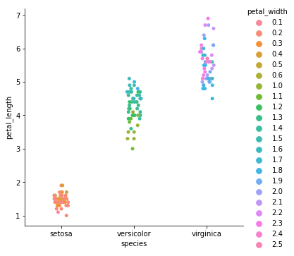

```python
# Catplot
sns.catplot(x = 'species', y = 'petal_length', hue = 'petal_width', data = iris)
```

This categorical plot suggest that the Virginica species have the longest petal lengths and its petal widths are concentrated in the range 1.5-2.3 while that of the Setosa has its width concentrated in the range 0.1-0.4. The Versicolor species has its petal length intermediate to the other two and its petal width ranges from 1.0 - 1.7.

```python
# Correlation
iris.corr()
```

|  | sepal_length | sepal_width | petal_length | petal_width |
| --- | --- | --- | --- | --- |
| sepal_length | 1.000000 | -0.117570 | 0.871754 | 0.817941 |
| sepal_width | -0.117570 | 1.000000 | -0.428440 | -0.366126 |
| petal_length | 0.871754 | -0.428440 | 1.000000 | 0.962865 |
| petal_width | 0.817941 | -0.366126 | 0.962865 | 1.000000 |

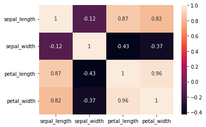

```python
# Heatmap
sns.heatmap(iris.corr(), annot = True)
```

>0.5 highly positive directly proportional <0.5 no correlation or less correlation - can drop this column >-0.5 highly negative inversely proportional